# Stackoverflow Survey 2019

Erstellt von 4757202

# Einbindung der Datenbank

```r
# Setzen der working directory
setwd("C:/Users/buehring/Desktop/Workspace/02_DHBW/01_Semester/5. Semester/Datenanalyse mit R/Stackoverflow_Developer_Survey_2019/Developer_Survey_2019")
```

```r
# Bibliothek zum Verbinden der Datenbank
library(DBI)

# Verbindung zur Datenbank herstellen
connection <- dbConnect(RSQLite::SQLite(), "survey.db")

# Datenbank einlesen
tableName <- "results"
dbReadTable(connection, tableName)
```

[output not shown]

[output cut: 990 more lines]

# Beschreibung der Daten

Bei dem Datensatz handelt es sich um die vollständigen, bereinigten Ergebnisse der Stack Overflow-Entwicklerumfrage 2019. Die Umfrage wurde vom 23. Januar bis 14. Februar 2019 durchgeführt. Die durchschnittliche Zeit, die für qualifizierte Beantwortungen für die Umfrage aufgewendet wurde, betrug 23,3 Minuten. Der Datensatz umfässt 85 Spalten und enthält über 88000 Zeilen.

# Umfrageteilnehmer

Zunächst wird in diesem Kapitel eine Übersicht über die Umfrageteilnehmer erstellt.

## Ein allgemeiner Überblick mittels Geovisualisierung

Quelle Geovisualisierung: https://slcladal.github.io/maps.html#Introduction

```r
# SQL query ausführen
countries <- dbGetQuery(connection, "SELECT country FROM results")

# in Dataframe umwandeln
countryFreq <- as.data.frame(table(countries))

# Bibliothek zur Darstellung der Weltkarte
library(rworldmap)
# Daten aus Dataframe werden auf eine Karte übertragen
visitedMap <- joinCountryData2Map(countryFreq,
                                  joinCode = "NAME",
                                  nameJoinColumn = "countries")
```

```
173 codes from your data successfully matched countries in the map
6 codes from your data failed to match with a country code in the map
72 codes from the map weren't represented in your data
```

173 der 179 Länder konnten korrekt zugewiesen werden. Die 6 fehlenden Länder vermutlich aufgrund ihrer Schreibweise im Datensatz nicht zugewiesen werden.

```r
# Wissenschaftliche Schreibweise von Zahlen deaktivieren (z.B. 1e +05)
options(scipen=999)

# Parameter der Karte bestimmen (z.B. Farben, Titel, ...)
mapParams <- mapCountryData(visitedMap,
                            nameColumnToPlot="Freq",
                            oceanCol = "azure2",
                            numCats=10,
                            catMethod=c(1,10,100,1000,10000,100000),
                            missingCountryCol = gray(.8),
                            colourPalette = c("coral",
                                              "coral2",
                                              "coral3", "orangered",
                                              "orangered3", "orangered4"),
                            addLegend = FALSE,
                            mapTitle = "Anzahl der Umfrageteilnehmer - Verteilung nach Region",
                            border = NA)
```

```
6 colours specified and 5 required, using interpolation to calculate colours
```

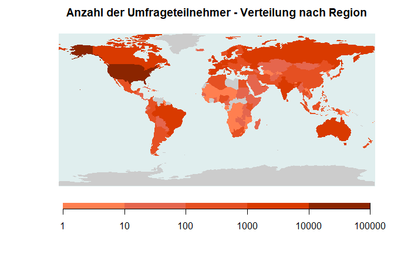

```r
# Legende hinzufügen und Karte anzeigen
do.call(addMapLegend, c(mapParams, legendLabels="all",
                       legendWidth=0.5,
                       legendIntervals="page",
                       legendMar=4))
```

### Nordamerika

Die USA kann die höchste Anzahl an Umfrageteilnehmern aufweisen.

```r
countryFreq[which(countryFreq$Freq == max(countryFreq$Freq)), ]
```

|  | countries | Freq |
| --- | --- | --- |
| 172 | United States | 20949 |

Dies ist vermutlich darauf zurückzuführen, dass Stackoverflow eine englischsprachige Plattform ist und die USA eine große Population und die meisten Englischsprecher auf der Welt besitzt.

Auch Kanada kann eine hohe Teilnehmeranzahl zwischen 1000 und 10000 Teilnehmern aufweisen.

### Europa

Zunächst schauen wir uns Europa genauer an, da es auf der Karte ziemlich klein ist.

```r
# Parameter der Karte bestimmen (z.B. Farben, Titel, ...)
mapParams <- mapCountryData(visitedMap,
                            nameColumnToPlot="Freq",
                            oceanCol = "azure2",
                            numCats=10,
                            catMethod=c(1,10,100,1000,10000,100000),
                            missingCountryCol = gray(.8),
                            colourPalette = c("coral",
                                              "coral2",
                                              "coral3", "orangered",
                                              "orangered3", "orangered4"),
                            addLegend = FALSE,
                            mapRegion = "Europe",
                            mapTitle = "Anzahl der Umfrageteilnehmer - Europa",
                            border = NA)
```

```
6 colours specified and 5 required, using interpolation to calculate colours
```

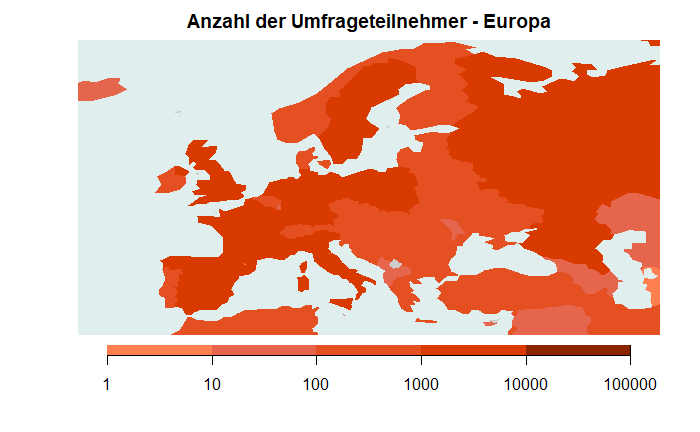

```r
# Legende hinzufügen und Karte anzeigen
do.call(addMapLegend, c(mapParams, legendLabels="all",
                       legendWidth=0.5,
                       legendIntervals="page",
                       legendMar=4))
```

In Zentral- und Westeuropa haben in der Regel zwischen 1000 und 10000 Personen pro Land an der Umfrage teilgenommen, in Osteuropa sinkt diese Zahl in den meisten Fällen auf 100 bis 1000 Antworten. Die Abnahme in Osteuropa ist vermutlich einerseits auf die geringeren Bevölkerungszahlen, andererseits aber auch auf die wirtschaftliche Situation und den durchschnittlichen Bildungsgrad der Länder zurückzuführen.

### Afrika

Besonders im afrikanischen Raum ist die Anzahl der Umfrageteilnehmer pro Land gering. Während in seltenen Fällen die Anzahl der Teilnehmer zwischen 100 und 1000 liegt, ist diese in der Regel zwischen 1 und 10 oder zwischen 10 und 100 Teilnehmern. In seltenen Fällen gibt es keine Teilnehmer aus Ländern in Afrika.

## Länder mit der größten Teilnehmeranzahl

Die 5 Länder mit den meisten Teilnehmern sind die USA, Indien, Deutschland, UK und Kanada.

```r
df_sorted <- countryFreq[order(-countryFreq$Freq), ]
head(df_sorted, 5)
```

|  | countries | Freq |
| --- | --- | --- |
| 172 | United States | 20949 |
| 71 | India | 9061 |
| 60 | Germany | 5866 |
| 170 | United Kingdom | 5737 |
| 31 | Canada | 3395 |

## Geschlechterverteilung

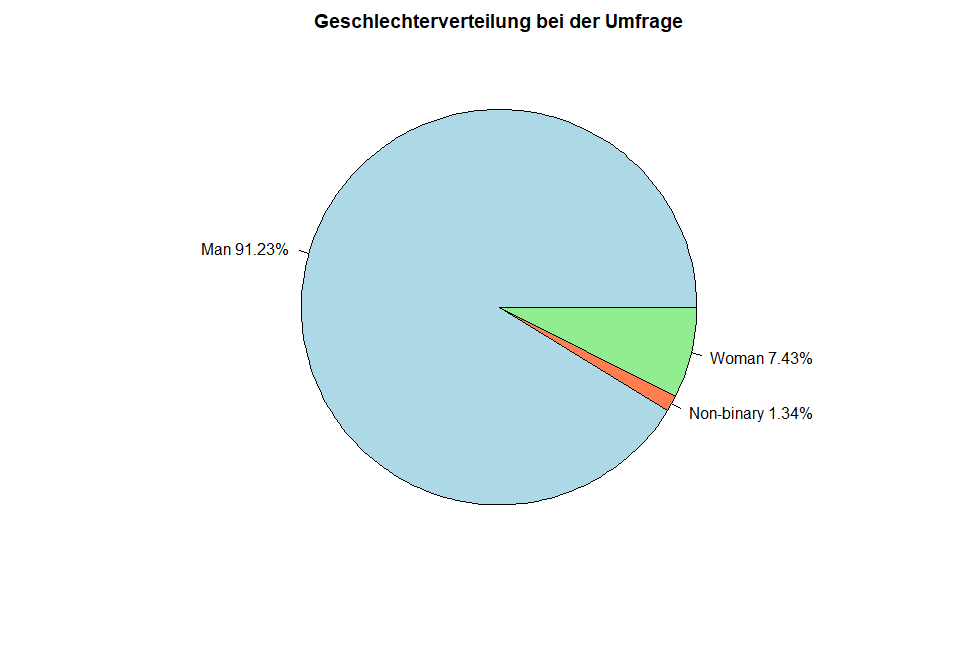

```r
library(dplyr)
# SQL Befehl ausführen
gender <- dbGetQuery(connection, "SELECT Gender FROM results")

# Unterkategorien der Geschlechtsmindeheiten unter "Non-Binary" zusammenfassen
gender <- mutate(gender, Gender=ifelse(grepl("Non-binary", Gender, ignore.case = T), "Non-binary", ifelse(grepl("Woman;Man", Gender, ignore.case = T), "Non-binary", Gender)))

gender_df <- as.data.frame(table(gender))

pct <- round(gender_df$Freq/sum(gender_df$Freq)*100, 2)

labels <- paste(gender_df$gender, pct)

labels <- paste(labels, "%", sep="")

colors <- c("light blue", "coral", "light green")

pie(gender_df$Freq, labels=labels, main="Geschlechterverteilung bei der Umfrage",
    col=colors)
```

Etwa 91% der Umfrageteilnehmer sind Männer, 7% sind Frauen und etwa 1% identifiziert sich mit keinem der traditionellen Geschlechter. Die große Mehrheit von Männern ist zurückzuführen auf die starke Männerdominanz in der IT-Branche.

## Verteilung nach Kontinent

Zunächst wird den Ländern mit der Bibliothek “countrycode” ihr passender Kontinent zugewiesen.

```r
# SQL Befehl ausführen
country_ethnicity_gender <- dbGetQuery(connection, "SELECT Country, Ethnicity, Gender FROM results")

# Unterkategorien der Geschlechtsmindeheiten unter "Non-Binary" zusammenfassen
country_ethnicity_gender <- mutate(country_ethnicity_gender, Gender=ifelse(grepl("Non-binary", Gender, ignore.case = T), "Non-binary", ifelse(grepl("Woman;Man", Gender, ignore.case = T), "Non-binary", Gender)))

# Bibliothek zum Zuteilen der Kontinente
library(countrycode)
# Erstellen einer Kontinentspalte, welche befüllt wird
country_ethnicity_gender$Continent <- countrycode(sourcevar = country_ethnicity_gender[, "Country"],
                            origin = "country.name",
                            destination = "continent")
```

```
Some values were not matched unambiguously: Other Country (Not Listed Above)
```

```r
# Ausgabe
head(country_ethnicity_gender, 5)
```

|  | Country | Ethnicity | Gender | Continent |
| --- | --- | --- | --- | --- |
| 1 | United Kingdom | NA | Man | Europe |
| 2 | Bosnia and Herzegovina | NA | Man | Europe |
| 3 | Thailand | NA | Man | Asia |
| 4 | United States | White or of European descent | Man | Americas |
| 5 | Ukraine | White or of European descent;Multiracial | Man | Europe |

Anschließend kann ein Barplot erstellt werden, um sich eine Übersicht zu verschaffen.

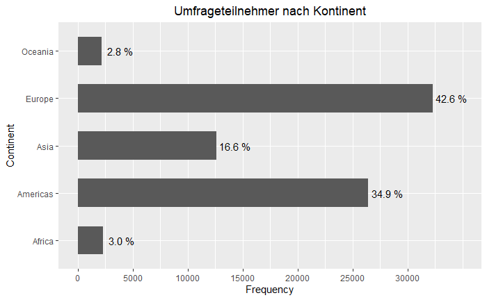

```r
country_ethnicity_gender_clean <- country_ethnicity_gender[complete.cases(country_ethnicity_gender), ]

library(ggplot2)
# Barplot der Kontinente
ggplot(country_ethnicity_gender_clean, aes(x=Continent)) +
  geom_bar(stat='count', width = 0.6) +
  xlab("Continent") +
  ylab("Frequency") +
  scale_y_continuous(limits = c(0, 35000), breaks = seq (0, 30000, 5000)) +
  ggtitle("Umfrageteilnehmer nach Kontinent") +
  theme(plot.title = element_text(hjust = 0.5)) +
  coord_flip() +
  geom_text(aes(label=stat(paste(format(round(count/lengths(country_ethnicity_gender_clean)*100, 1)), "%"))),
            stat="count",
            hjust=-0.1) # Werte in Prozent anzeigen lassen
```

Europa liefert mit fast 43% gesamtheitlich die größte Anzahl an Teilnehmern. Auf dem zweiten Rang steht Amerika (Achtung: Nord- und Südamerika wurden zusammengefasst) mit 34.9%, darauf folgt Asien mit 16,6%.

Ozeanien und Afrika lieferten mit 2,8% und 3,0% die geringste Anzahl an Teilnehmern.

## Geschlechterverteilung nach Kontinent

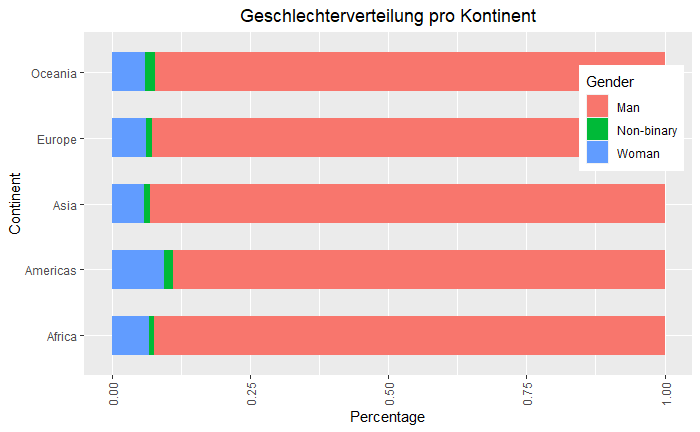

```r
ggplot(country_ethnicity_gender_clean, aes(x=Continent, fill=Gender)) +
  geom_bar(stat='count', width = 0.6, position = 'fill') +
  xlab("Continent") +
  ylab("Percentage") +
  theme(axis.text.x = element_text(angle = 90, vjust = 0.5, hjust=1), legend.position = c(0.9, 0.75)) +
  coord_flip() +
  ggtitle("Geschlechterverteilung pro Kontinent") +
  theme(plot.title = element_text(hjust = 0.5))
```

Betrachtet man die Geschlechterverteilung nach Kontinent, so erkennt man, dass Amerika den höchsten Anteil an Frauen aufweist. Die restlichen vier Kontinente haben eine ähnliche Geschlechterverteilung. Die Teilnehmer mit nichtbinären Geschlechtern sind prozentual etwas häufiger in Ozeanien und Amerika zu finden, jedoch ist die Verteilung auf den Kontinenten etwa gleich.

# Jobzufriedenheit

```r
# SQL Befehl ausführen
job_sat <- dbGetQuery(connection, "SELECT JobSat From results")

# Null-Werte entfernen
job_sat_clean <- na.omit(job_sat)
```

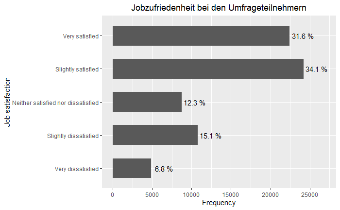

```r
library(ggplot2)
library(dplyr)
library(forcats)
job_sat_clean %>%
  mutate(job_sat_order = fct_relevel(JobSat,
            "Very dissatisfied", "Slightly dissatisfied",
            "Neither satisfied nor dissatisfied",
            "Slightly satisfied", "Very satisfied")) %>%
  ggplot(aes(x=job_sat_order)) +
  geom_bar(width = 0.6) +
  scale_y_continuous(limits = c(0, 27000), breaks = seq (0, 30000, 5000)) +
  xlab("Job satisfaction") +
  ylab("Frequency") +
  coord_flip() +
  ggtitle("Jobzufriedenheit bei den Umfrageteilnehmern") +
  theme(plot.title = element_text(hjust = 0.5)) +
  geom_text(aes(label=stat(paste(format(round(count/lengths(job_sat_clean)*100, 1)), "%"))),
            stat="count",
            hjust=-0.1) # Werte in Prozent anzeigen lassen
```

Fast zwei Drittel der Befragten sind entweder zufrieden oder sehr zufrieden mit ihrem Job. Etwas mehr als 12% sind weder zufrieden noch unzufrieden und etwa 22% der Befragten sind entweder unzufrieden oder sehr unzufrieden.

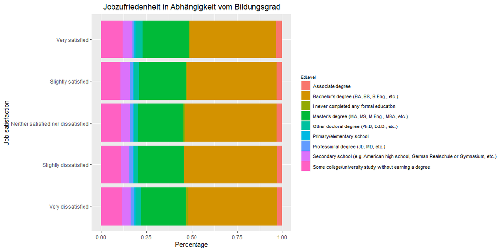

```r
# Bibliotheken importieren
library(ggplot2)
library(dplyr)
library(forcats)

# SQL Befehl ausführen
job_sat_ed <- dbGetQuery(connection, "SELECT JobSat, Edlevel From results")

# Nur komplette Zeilen übernehmen (also alle NA-Werte entfernen)
job_sat_ed_clean <- job_sat_ed[complete.cases(job_sat_ed), ]

job_sat_ed_clean %>%
  mutate(job_sat_ed_order = fct_relevel(JobSat,
            "Very dissatisfied", "Slightly dissatisfied",
            "Neither satisfied nor dissatisfied",
            "Slightly satisfied", "Very satisfied")) %>%
  ggplot(aes(fill = EdLevel, x=job_sat_ed_order)) +
  geom_bar(position="fill") +
  ggtitle("Jobzufriedenheit in Abhängigkeit vom Bildungsgrad") +
  theme(plot.title = element_text(hjust = 0.5)) +
  xlab("Job satisfaction") +
  ylab("Percentage") +
  coord_flip() +
  theme(legend.title = element_text(color = "black", size = 7),
        legend.text = element_text(color = "black", size = 8))
```

In Abhängigkeit vom Bildungsgrad lassen sich bei der Jobzufriedenheit keine großen Unterschiede erkennen.

# Karriere-Zufriedenheit

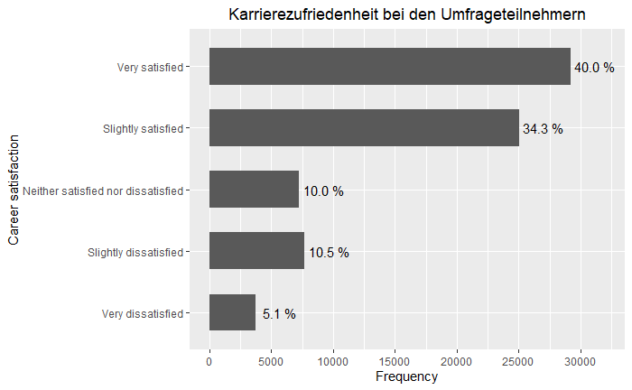

```r
library(ggplot2)
library(dplyr)
library(forcats)

car_sat <- dbGetQuery(connection, "SELECT CareerSat FROM results")

car_sat_clean <- na.omit(car_sat)

car_sat_clean %>%
  mutate(car_sat_order = fct_relevel(CareerSat,
            "Very dissatisfied", "Slightly dissatisfied",
            "Neither satisfied nor dissatisfied",
            "Slightly satisfied", "Very satisfied")) %>%
  ggplot(aes(x=car_sat_order)) +
  geom_bar(width = 0.6) +
  scale_y_continuous(limits = c(0, 32000), breaks = seq (0, 30000, 5000)) +
  xlab("Career satisfaction") +
  ylab("Frequency") +
  coord_flip() +
  ggtitle("Karrierezufriedenheit bei den Umfrageteilnehmern") +
  theme(plot.title = element_text(hjust = 0.5)) +
  geom_text(aes(label=stat(paste(format(round(count/lengths(car_sat_clean)*100, 1)), "%"))),
            stat="count",
            hjust=-0.1) # Werte in Prozent anzeigen lassen
```

40% der Umfrageteilnehmer sind mit ihrer Karriere sehr zufrieden und etwa 34% geben an, zufrieden zu sein. Somit sind fast 3/4 der Umfrageteilnehmer zufrieden mit ihrer Karriere.

10% geben an, weder zufrieden noch unzufrieden zu sein. 10,5% der Umfrageteilnehmer sind nicht mit ihrer Karriere zufrieden, nur etwa 5% sind sehr unzufrieden.

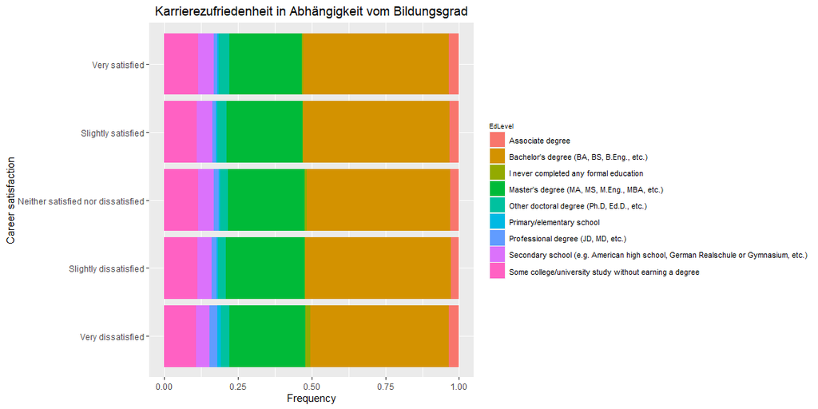

```r
library(ggplot2)
library(dplyr)
library(forcats)

career_sat_ed <- dbGetQuery(connection, "SELECT CareerSat, Edlevel From results")

career_sat_ed_clean <- career_sat_ed[complete.cases(career_sat_ed), ]

career_sat_ed_clean %>%
  mutate(career_sat_ed_order = fct_relevel(CareerSat,
            "Very dissatisfied", "Slightly dissatisfied",
            "Neither satisfied nor dissatisfied",
            "Slightly satisfied", "Very satisfied")) %>%
  ggplot(aes(fill = EdLevel, x=career_sat_ed_order)) +
  geom_bar(position="fill") +
  ggtitle("Karrierezufriedenheit in Abhängigkeit vom Bildungsgrad") +
  theme(plot.title = element_text(hjust = 0.5)) +
  xlab("Career satisfaction") +
  ylab("Frequency") +
  coord_flip() +
  theme(legend.title = element_text(color = "black", size = 7),
        legend.text = element_text(color = "black", size = 8))
```

In Abhängigkeit vom Bildungsgrad lassen sich auch bei der Karrierezufriedenheit keine großen Unterschiede erkennen. Auffällig ist, dass der prozentuale Anteil der Menschen ohne “formal education” bei den sehr unzufriedenen am größten ist.

# Lohnniveau Länderverteilung

```r
# SQL Befehl ausführen
salary <- dbGetQuery(connection, "SELECT ConvertedComp, Country FROM results")

# Identifizieren und Entfernen von Ausreißern
outliers <- boxplot(salary$ConvertedComp, plot=FALSE)$out
salary_clean <- salary[-which(salary$ConvertedComp %in% outliers), ]

# In Dataframe umwandeln
salary_df <- as.data.frame(salary_clean)

# Durchschnitt berechnen
average_salary <- aggregate(ConvertedComp ~ Country, salary_df, mean)

# Absteigend sortieren
average_salary_sorted <- average_salary[order(-average_salary$ConvertedComp), ]

average_salary_sorted
```

|  | Country | ConvertedComp |
| --- | --- | --- |
| 4 | Andorra | 160931.000 |
| 39 | Democratic Republic of the Congo | 110484.000 |
| 152 | United States | 105122.135 |
| 136 | Switzerland | 87753.245 |
| 68 | Israel | 87004.917 |
| 40 | Denmark | 83229.275 |
| 103 | Norway | 81176.433 |
| 8 | Australia | 78487.502 |
| 62 | Iceland | 76764.889 |
| 67 | Ireland | 76433.800 |

[output cut: 149 more lines]

```r
# Wissenschaftliche Schreibweise von Zahlen deaktivieren (z.B. 1e +05)
options(scipen=999)

salaryMap <- joinCountryData2Map(average_salary,
                                  joinCode = "NAME",
                                  nameJoinColumn = "Country")
```

```
153 codes from your data successfully matched countries in the map
6 codes from your data failed to match with a country code in the map
91 codes from the map weren't represented in your data
```

```r
# Parameter der Karte bestimmen (z.B. Farben, Titel, ...)
mapParams <- mapCountryData(salaryMap,
                            nameColumnToPlot="ConvertedComp",
                            oceanCol = "azure2",
                            numCats=10,
                            catMethod=c(0,5000,10000,25000,50000,100000,170000),
                            missingCountryCol = gray(.8),
                            colourPalette = c("coral",
                                              "coral2",
                                              "orangered",
                                              "orangered3",
                                              "orangered4"),
                            addLegend = FALSE,
                            mapTitle = "Durchschnittliches Jahresgehalt pro Land",
                            border = NA)
```

```
5 colours specified and 6 required, using interpolation to calculate colours
```

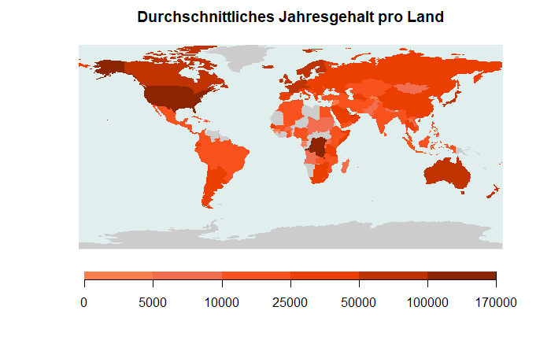

```r
# Legende hinzufügen und Karte anzeigen
do.call(addMapLegend, c(mapParams, legendLabels="all",
                       legendWidth=0.5,
                       legendIntervals="page",
                       legendMar=4))
```

Die durchschnittlichen Jahresgehälter entsprechen ungefähr der Verteilung der Bruttoinlandsprodukte der Länder (siehe https://ourworldindata.org/grapher/gdp-per-capita-worldbank). Eine starke Ausnahme stellt hier die Demokratische Republik Kongo dar. Auch nach dem Entfernen von Ausreißern steht das Land an zweiter Stelle was den Jahresverdienst angeht.

# Lohn in Abhängigkeit von Berufserfahrung

```r
# SQL Befehl durchführen
salaryByExperience <- dbGetQuery(connection, "SELECT ConvertedComp, YearsCodePro FROM results")

# Identifizieren und Entfernen von Ausreißern
outliers <- boxplot(salaryByExperience$ConvertedComp, plot=FALSE)$out
salaryByExperience <- salaryByExperience[-which(salaryByExperience$ConvertedComp %in% outliers), ]

# "Less than 1 year" zu 0 ändern (befinden sich im 0ten Jahr)
salaryByExperience <- mutate(salaryByExperience, YearsCodePro=ifelse(grepl("Less than 1 year", YearsCodePro, ignore.case = T), 0, YearsCodePro))

# In Integer umwandeln
salaryByExperience$YearsCodePro <- as.integer(salaryByExperience$YearsCodePro)
```

```
NAs durch Umwandlung erzeugt
```

```r
# Nur komplette Datensätze behalten (NA entfernen)
salaryByExperience_clean <- salaryByExperience[complete.cases(salaryByExperience), ]
```

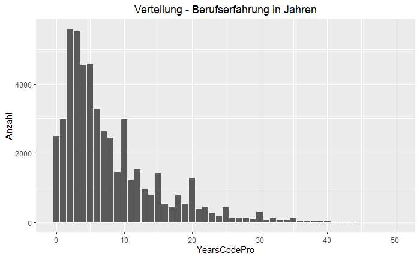

```r
library(ggplot2)
ggplot(salaryByExperience_clean, aes(x=YearsCodePro)) +
  geom_bar(stat = 'count') +
  ylab("Anzahl") +
  ggtitle("Verteilung - Berufserfahrung in Jahren") +
  theme(plot.title = element_text(hjust = 0.5))
```

Die meisten Teilnehmer besitzen unter 10 Jahre professioneller Berufserfahrung im Programmieren.

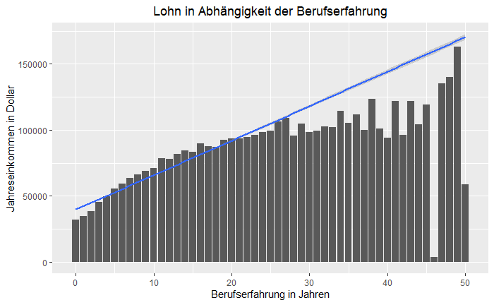

```r
library(ggplot2)
ggplot(salaryByExperience_clean, aes(x=YearsCodePro, y=ConvertedComp)) +
  geom_bar(stat = 'summary', fun='mean') +
  geom_smooth(method = "lm") +
  xlab("Berufserfahrung in Jahren") +
  ylab("Jahreseinkommen in Dollar") +
  ggtitle("Lohn in Abhängigkeit der Berufserfahrung") +
  theme(plot.title = element_text(hjust = 0.5))
```

```r
NA
NA
```

Es lässt sich bis zu etwa 25 Jahren Berufserfahrung ein klarer Trend von steigendem Lohn erkennen, danach flacht die Steigung etwas ab. Ab etwa 30 Jahren Berufserfahrung sind die Werte unzuverlässiger, da es in diesen Bereichen nur wenige Umfrageteilnehmer und somit wenige Werte gibt.

# Gender-Pay-Gap

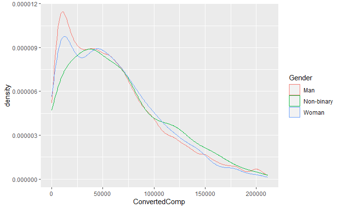

```r
# SQL Befehl ausführen
salaryByGender <- dbGetQuery(connection, "SELECT Country, ConvertedComp, Gender, YearsCodePro FROM results")

# Unterkategorien der Geschlechtsmindeheiten unter "Non-Binary" zusammenfassen
salaryByGender <- mutate(salaryByGender, Gender=ifelse(grepl("Non-binary", Gender, ignore.case = T), "Non-binary", ifelse(grepl("Woman;Man", Gender, ignore.case = T), "Non-binary", Gender)))

# Nur komplette Datensätze behalten (NA entfernen)
salaryByGender <- salaryByGender[complete.cases(salaryByGender), ]

# Identifizieren und Entfernen von Ausreißern
outliers <- boxplot(salaryByGender$ConvertedComp, plot=FALSE)$out
salaryByGender_clean <- salaryByGender[-which(salaryByGender$ConvertedComp %in% outliers), ]

library(ggplot2)
ggplot(salaryByGender_clean, aes(x=ConvertedComp, color=Gender)) +
  geom_density()
```

```r
sorted_salary_by_gender <- salaryByGender_clean %>%
  group_by(Gender) %>%
  summarise(AverageSalary=mean(ConvertedComp))
sorted_salary_by_gender
```

| Gender | AverageSalary |
| --- | --- |
| Man | 60115.22 |
| Non-binary | 65280.49 |
| Woman | 60428.63 |

Das Durchschnittsgehalt ist in dieser Umfrage bei Männern und Frauen fast gleich und unterscheidet sich in etwa nur um 300 Dollar im Jahr zu Gunsten der Frauen. Teilnehmer, welche sich keine Geschlecht zuordnen, verdienen in dieser Umfrage im Durchschnitt sogar mehr.

Die Gender Pay Gap spiegelt sich gesamtheitlich in dieser Umfrage nicht wider.

## Verteilung pro Land

```r
library(dplyr)

sortedSalaryByGenderCountry <- salaryByGender_clean %>%
  group_by(Country, Gender) %>%
  summarise(AverageSalary=(mean(ConvertedComp)))
sortedSalaryByGenderCountry
```

| Country | Gender | AverageSalary |
| --- | --- | --- |
| Afghanistan | Man | 8778.000 |
| Albania | Man | 24126.214 |
| Albania | Woman | 9798.000 |
| Algeria | Man | 10957.657 |
| Algeria | Non-binary | 10150.000 |
| Algeria | Woman | 25963.000 |
| Andorra | Man | 160931.000 |
| Angola | Man | 7764.000 |
| Argentina | Man | 25574.940 |
| Argentina | Non-binary | 18344.000 |

[output cut: 318 more lines]

## Gender Pay Gap in Abhängigkeit zur Berufserfahrung

```r
# "Less than 1 year" zu 0 ändern (befinden sich im 0ten Jahr)
salaryByGender_clean <- mutate(salaryByGender_clean, YearsCodePro=ifelse(grepl("Less than 1 year", YearsCodePro, ignore.case = T), 0, YearsCodePro))

# In Integer umwandeln
salaryByGender_clean$YearsCodePro <- as.integer(salaryByGender_clean$YearsCodePro)
```

```
NAs durch Umwandlung erzeugt
```

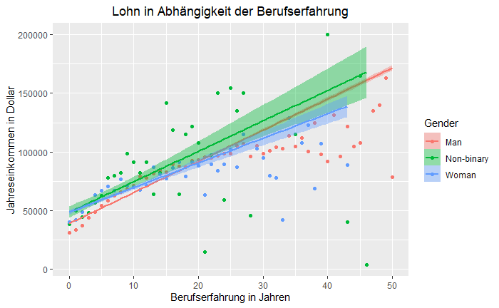

```r
library(ggplot2)
ggplot(salaryByGender_clean, aes(x=YearsCodePro, y=ConvertedComp, color=Gender, group=Gender, fill=Gender)) +
  geom_point(stat = 'summary', fun='mean') +
  geom_smooth(aes(fill=Gender), method = "lm") +
  xlab("Berufserfahrung in Jahren") +
  ylab("Jahreseinkommen in Dollar") +
  ggtitle("Lohn in Abhängigkeit der Berufserfahrung") +
  theme(plot.title = element_text(hjust = 0.5))
```

Beim Gehalt der Männer besitzen die Daten keine große Streuung. Bei Frauen und nicht-binären existieren weniger Daten, was vermutlich für eine größere Streuung der Daten sorgt. In diesem Beispiel ist zu erkennen, dass die Umfrageteilnehmerinnen durchschnittlich ein größeres Gehalt beim Berufseinstieg bekommen haben, allerdings stieg das Gehalt der Männer mit steigender Berufserfahrung mehr an. Mögliche Ursachen könnten beispielsweise die Gründung einer Familie sein, bei der Frauen i.d.R. eine längere Berufspause als Männer einlegen und in dieser Zeit weniger Gehaltserhöhungen bekommen.